# Taking previous 2 years data of stock ADANIPORTS

## p=1,d=1,q=1

```python
modelarima2=ARIMA(data['close '],order=(1,1,1))
results2=modelarima2.fit()
results2.summary()
```

SARIMAX Results

| Dep. Variable: | close | No. Observations: | 498 |
| --- | --- | --- | --- |
| Model: | ARIMA(1, 1, 1) | Log Likelihood | -2047.675 |
| Date: | Wed, 06 Apr 2022 | AIC | 4101.351 |
| Time: | 19:42:37 | BIC | 4113.976 |
| Sample: | 0 | HQIC | 4106.306 |
|  | - 498 |  |  |
| Covariance Type: | opg |  |  |

|  | coef | std err | z | P>\|z\| | [0.025 | 0.975] |
| --- | --- | --- | --- | --- | --- | --- |
| ar.L1 | -0.5798 | 0.137 | -4.247 | 0.000 | -0.847 | -0.312 |
| ma.L1 | 0.6865 | 0.117 | 5.891 | 0.000 | 0.458 | 0.915 |
| sigma2 | 221.8939 | 6.837 | 32.455 | 0.000 | 208.494 | 235.294 |

| Ljung-Box (Q): | 49.90 | Jarque-Bera (JB): | 930.15 |
| --- | --- | --- | --- |
| Prob(Q): | 0.14 | Prob(JB): | 0.00 |
| Heteroskedasticity (H): | 4.18 | Skew: | -0.07 |
| Prob(H) (two-sided): | 0.00 | Kurtosis: | 9.70 |

Warnings:  
[1] Covariance matrix calculated using the outer product of gradients (complex-step).

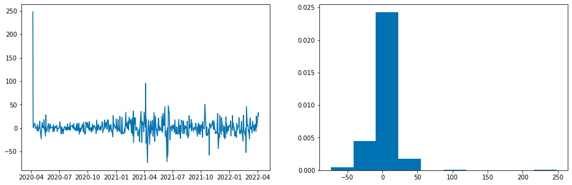

```python
residuals2=pd.DataFrame(results2.resid)

fig,(ax1,ax2)=plt.subplots(1,2,figsize=(16,5))
ax1.plot(residuals2)
ax2.hist(residuals2,density=True)
plt.show()
```

```python
results2.forecast(15)
```

```
498    848.764907
499    848.350436
500    848.590728
501    848.451417
502    848.532183
503    848.485359
504    848.512505
505    848.496767
506    848.505891
507    848.500601
508    848.503668
509    848.501890
510    848.502921
511    848.502323
512    848.502670
dtype: float64
```

```python
results2.predict()
```

```
Date
2020-04-07      0.000000
2020-04-08    248.105330
2020-04-09    251.108200
2020-04-13    251.830573
2020-04-15    264.038985
                 ...
2022-03-30    765.269560
2022-03-31    765.702982
2022-04-01    776.091269
2022-04-04    785.685003
2022-04-05    822.097406
Length: 498, dtype: float64
```

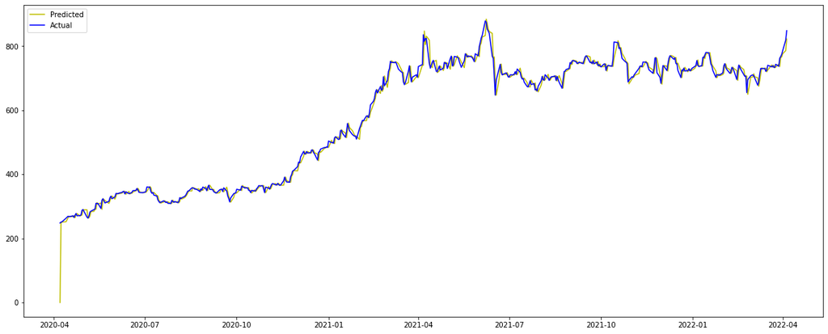

```python
# Actual Vs. Predicted
plt.figure(figsize=(20,8))
plt.plot(results2.predict(),color='y',label='Predicted')
plt.plot(data,color='b',label='Actual')
plt.legend(loc='best')
plt.show()
```

# Comments:

1. Both model of ARIMA(2,1,2) and ARIMA(1,1,1) are fitting well.
2. From the graph, we can see that the predicitng values are pretty close to actual values.
3. We can say that ARIMA model is fitted correctly.

```python
## Next 2 months prediction
date = pd.date_range(start='04/05/2022',end = '06/05/2022',freq='D')
len(date)
```

```
62
```

```python
forecast=pd.DataFrame({'Stock Price': list(results1.forecast(62))},index=date)
forecast
```

|  | Stock Price |
| --- | --- |
| 2022-04-05 | 845.583148 |
| 2022-04-06 | 841.459272 |
| 2022-04-07 | 839.287320 |
| 2022-04-08 | 837.054485 |
| 2022-04-09 | 835.556103 |
| ... | ... |
| 2022-06-01 | 829.645601 |
| 2022-06-02 | 829.645597 |
| 2022-06-03 | 829.645594 |
| 2022-06-04 | 829.645592 |
| 2022-06-05 | 829.645590 |

62 rows × 1 columns

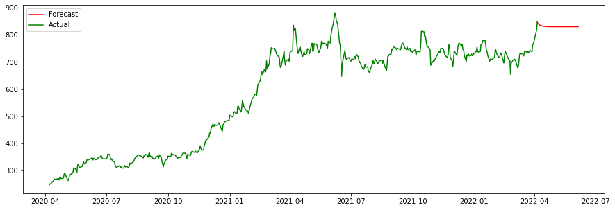

```python
# Forecast
plt.figure(figsize=(15,5))
plt.plot(forecast,color='r',label='Forecast')
plt.plot(data,color='g',label='Actual')
plt.legend(loc='best')
plt.show()
```

# Comments:

1. The forecasted price is decreasing and intuitively we can also say that stock is facing resistance around 850-880.
2. According to chart, we can say that 720-780 range is a good support range.
3. The ARIMA(2,1,2) giving expected results.